# Project 2: Biomedical & Clinical Informatics

Merrimack College DSE6630: Healthcare & Life Sciences Analytics

Ryan Canfield, Malek Sabri, Tiffany Acosta

30 April 2024

# 1 Introduction

We will pick up where we left off in Demo 2 to prepare you for analysis. Although this is not going to be as exhaustive as we would like to do if we were doing a complete project, our goal is to see this project go from **messy data** $\rightarrow$ **prediction & interpretation**. After all, we need to give something to the patient advocacy watchdog that they can deploy!

## 1.1 Our Analysis Plan

Our goal is to see this analysis through to generate a predictive model that the advocacy group can use, and hopefully it will be a decent one. To ensure that it stands the best chance of being a good predictive model, our analysis plan includes all the key steps in the data science life cycle/project flow, including: **cleaning**, **exploration**, **feature selection**, **pre-processing**, **unsupervised machine learning exploration**, and **supervised modeling**. Whew!

Our specific plan is to perform two big analyses in the hopes of having a nice deliverable to present to our client. The first will be a **segmentation analysis**, or clustering analysis, which will attempt to group our hospitals together on the basis of their attributes and their pneumonia-related readmissions. Thie will be done using a combination of PCA and $k$-means. Our second analysis will be to perform supervised, predictive analysis using an elastic net, which conveniently combines a penalized regression with variable selection so we can point our clients down a path of hospital attributes to focus on, as well as a model they can use to make future predictions.

## 1.2 Your objective.

Your object is to work through this Project 2. You will have 31 Questions to answer as you work through this, just as with Project 1. Then, you will be able to choose your own adventure again to perform your own **clinical informatics** analysis:

#### Adventure 1. [Minimal coding, focus is on understanding cleaning, pre-processing, and the ML analyses we performed here.]

Choose ONE other condition (anything other than pneumonia) and run through the analyses again, using our same target variable. You will update your question, hypotheses, and predictions, but will be able to re-use all of the other code with very minor modifications. Credit will be based more on interpretation and not on coding.

#### Adventure 2. [More coding, but not as much, with a focus on the steps we’ve undertaken here and extending it to a new question & condition.]

Choose a slightly more complicated analysis to undertake, for example, focusing on surgical interventions (`HIP-KNEE` & `CABG`) or heart-related conditions (`HF`, `AMI`, & `CABG`). Coding should still be fairly minimal, but you are likely to run into problems with the code working exactly as-is, especially during cleaning. The advantage of this analysis is that it will be much more robust, have larger sample sizes, and would allow us to be able to say something far more informative to a class of patients (e.g., those considering undergoing surgical interventions).

#### Adventure 3. [Most coding, but no cleaning or pre-processing, with an emphasis entirely on the machine learning analyses.]

Continue with the pneumonia-related data that you have here, completely cleaned and pre-processed, and do two more unsupervised OR supervised analyses. For example, you could do another clustering method (e.g., kNN) and compare that to the clusters we will get in our analysis, or you could do a random forest like we did in the last module, or you could choose to do a Ridge and LASSO regression and compare those analyses to what we will get out of an Elastic Net. Any of these are fine, but you must **explain your decision** in your submission.

## 1.3 Code to help.

This time, I am doing things a little different from Project 1 to show you something new. Here, we are using the `source()` function to effectively use R like an **object-oriented language**. We can write code to do more tedious tasks, or even make our own **R package(!)** [not shown here] to deal with common or tedious tasks we do. The linked `answers_demo2.R` file contains all of my code to do the cleaning tasks from Demo 2, including my answers to the big functions I asked you to write in Questions 12 & 15).

For **Project 2**, you will have the option to **modify** and **run** the code in the `answers_demo2.R` file and run it in your markdown file, as I do below. Now, you don’t have to run the code right now unless you want to see it in action; if you do, make sure to give it a couple minutes to run, as it’s doing a lot in one fell swoop. Or, you can just skip ahead to the next section and load the data.

```
## [1] "Before encoding:"
##
##   Better than the National Benchmark No Different than National Benchmark
##                                  166                                 1517
##    Worse than the National Benchmark                                 <NA>
##                                   50                                 3083
## [1] "After encoding:"
##
##   -1    0    1 <NA>
##   50 1517  166 3083
## [1] "Before encoding:"
##
##       Better Than the National Rate No Different Than the National Rate
##                                 216                                3165
##        Worse Than the National Rate                                <NA>
##                                 133                                1302
## [1] "After encoding:"
##
##   -1    0    1 <NA>
##  133 3165  216 1302
## [1] "Before encoding:"
##
##       Better Than the National Rate No Different Than the National Rate
##                                  57                                2435
##        Worse Than the National Rate                                <NA>
##                                 111                                2213
## [1] "After encoding:"
##
##   -1    0    1 <NA>
##  111 2435   57 2213
## [1] "Before encoding:"
##
##       Better Than the National Rate No Different Than the National Rate
##                                  16                                2845
##        Worse Than the National Rate                                <NA>
##                                  74                                1881
## [1] "After encoding:"
##
##   -1    0    1 <NA>
##   74 2845   16 1881
```

[output cut: 23 more lines]

```
##  827 2285  402 1302
## [1] "Before encoding:"
##
##      Greater Than the National Average Payment
##                                            433
##         Less Than the National Average Payment
##                                            457
## No Different Than the National Average Payment
##                                           2445
##                                           <NA>
##                                           1481
## [1] "After encoding:"
##
##    0 <NA>
## 2445 2371
```

## 1.4 Load data from the end of the demo.

Load my version of the fully cleaned, encoded, & ready-to-proceed dataset from the end of Demo 2. These data are not yet ready for analysis (!) but we are picking up with that here.

```r
load("pneumoniaAnalyzefromDemo.Rdata")
```

# 2 Exploratory Data Analysis (Continued)

### 2.1 My solution: Which of the possible target (outcome) variables should we use?

My answer to **Question 18** from the Demo.

Now, I know I didn’t ask you to do it, but I will actually begin my assessment of which target is most appropriate by constructing a quick summary table. In my assessment of what is an appropriate target, I am including `ComparedToNational_Hospital return days for pneumonia patients` because this is our best assessment of how the hospital is performing relative to a national average. If we were interested in this as the **target**, we would need to perform a multinomial classification analysis - totally doable, but perhaps beyond our scope right now. :) So, instead, let’s use this category to help us contextualize our hospitals as we choose between `Predicted`, `Observed`, and `Expected` readmission rates, as well as the `Excess Readmission Ratio`.

I am also going to quickly break down the differences between the possible targets so we can make sure we really understand **what** they are measuring to allow us to make our most-informed selection of a target. Note: More information was found [in this PDF](https://qualitynet.cms.gov/files/5d0d3ae5764be766b0104c37?filename=Pneumo_ReadmMeasMethod.pdf).

Table 1. List of possible target variables from the Pneumonia-related hospital readmission data. Which one to choose?

| Possible Target | Description |
| --- | --- |
| `ComparedToNational_Hospital return days for pneumonia patients` | Hospital return days measures the number of days patients spent back in the hospital (in the emergency department, under observation, or in an inpatient unit) within 30 days after they were first trea… |
| `ExpectedReadmissionRate` | The expected number of readmissions in each hospital is estimated using its patient mix and an average hospital-specific intercept. It is thus indirectly standardized to other hospitals with similar c… |
| `PredictedReadmissionRate` | The number of readmissions within 30 days predicted based on the hospital’s performance with its observed case mix. The predicted number of readmissions is estimated using a hospital-specific intercep… |
| `ExcessReadmissionRatio` | The ratio of the predicted readmission rate to the expected readmission rate, based on an average hospital with similar patients. Performance is compared against a ratio of one, such that below one is… |
| `observed_readmission_rate` | Our calculation of the observed number of pneumonia-related readmissions within 30 days found by dividing the number of readmissions observed for the hospital during the given period by the number of … |

**Table 2. Possible target measure summaries**

| **Characteristic** | **N = 4,816**<sup>1</sup> |
| --- | --- |
| National Comparison Return Hospital Days |  |
| Better than average | 402 / 4,816 (8.3%) |
| Same as average | 2,285 / 4,816 (47%) |
| Worse than average | 827 / 4,816 (17%) |
| Unknown | 1,302 / 4,816 (27%) |
| Predicted Readmission Rate | 16.46 (1.93), 16.27 |
| (Missing) | 2,090 |
| Observed Readmission Rate | 17.1 (3.7), 16.9 |
| (Missing) | 2,603 |
| ExcessReadmissionRatio | 1.00 (0.06), 1.00 |
| (Missing) | 2,090 |
| Expected Readmission Rate | 16.43 (1.51), 16.39 |
| (Missing) | 2,090 |

<sup>1</sup> n / N (%); Mean (SD), Median

### 2.2 My answer to **Question 18** from the Demo.

If I know I want to **facet** plots, the first thing I have to do is reshape the data I want from *wide* into *long* format using, for example, the `pivot_longer()` function (the complement of `pivot_wider()` that we used in the Demo).

I don’t have to store it as a separate data frame (i.e., I can just pipe it directly into `ggplot()`!) but here I am choosing to so we can more easily make sure it’s reshaped correctly along the way. Thus, I am making a long-format version of the possible target variables called `longDataTarget` so that I can better decide which target to choose.

I mentioned `violin` and `density` plots specifically in Question 18 of Demo 2, as well as faceting. I am going to show you two ways to explore these data with these types of plots and you can decide which one(s) you find most informative here. You also may have thought of a better way to display the data too!

#### Example with `geom_violin()`:

Here I am leaving the `NA` data (which I relabelled as `Unknown`) to get a sense for the degree of missingness.

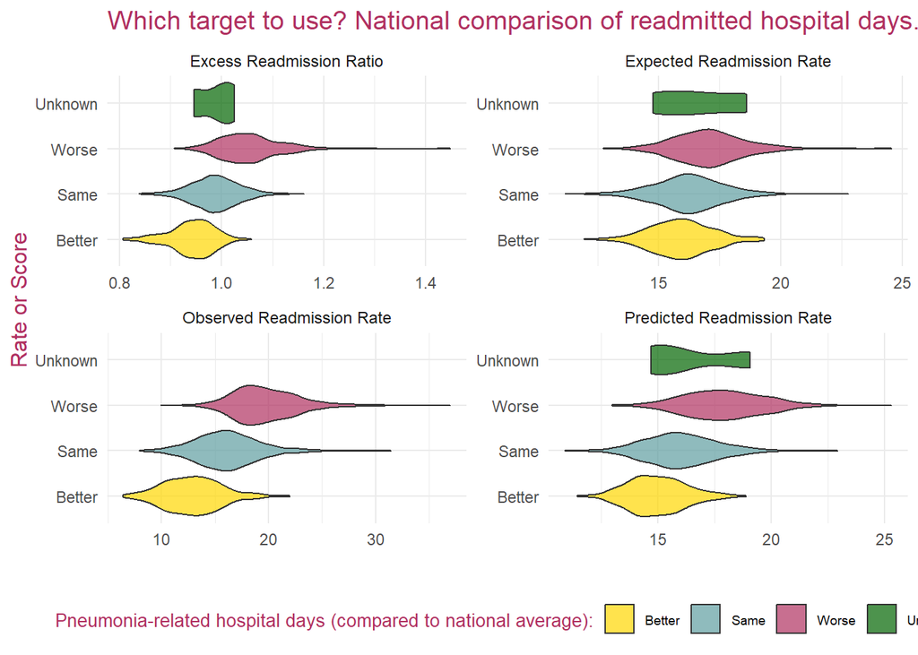

#### Example with `geom_density()`:

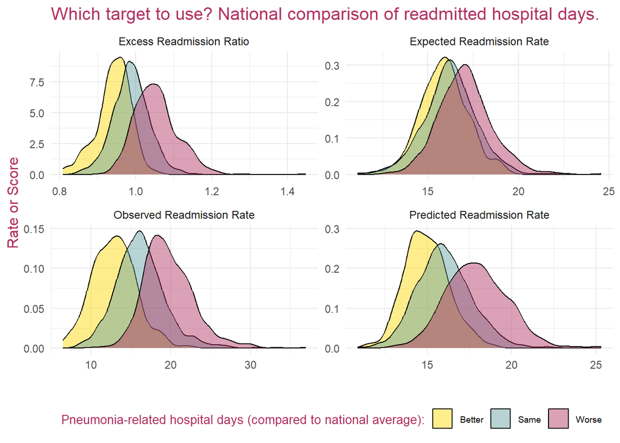

### 2.3 What is the distribution of various hospital metrics across pneumonia-related readmission as compared to the national average?

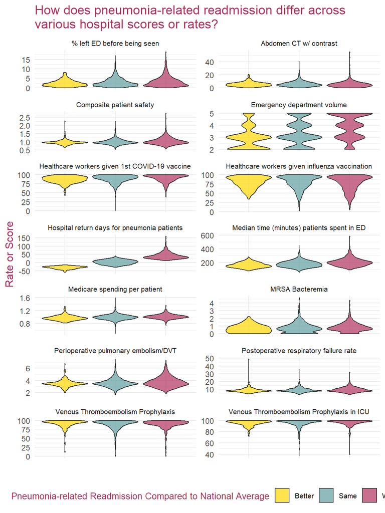

There is no obvious trend apparent from these distributions; this may suggest that whatever differences there are may be subtle. If any trend exists here at all, I do see shorter “tails” on the distributions for the hospitals performing better in terms of their hospital return days; perhaps these hospitals are more likely to perform consistently in other areas?

But given that histograms (or, here, **violin plots**) are not always best for seeing subtle trends, let us plot as scatter plots as well.

### 2.4 What is the relationship of pneumonia-related hospital readmissions to the various hospital metrics?

This would have been my solution to Question 18 on the Demo.

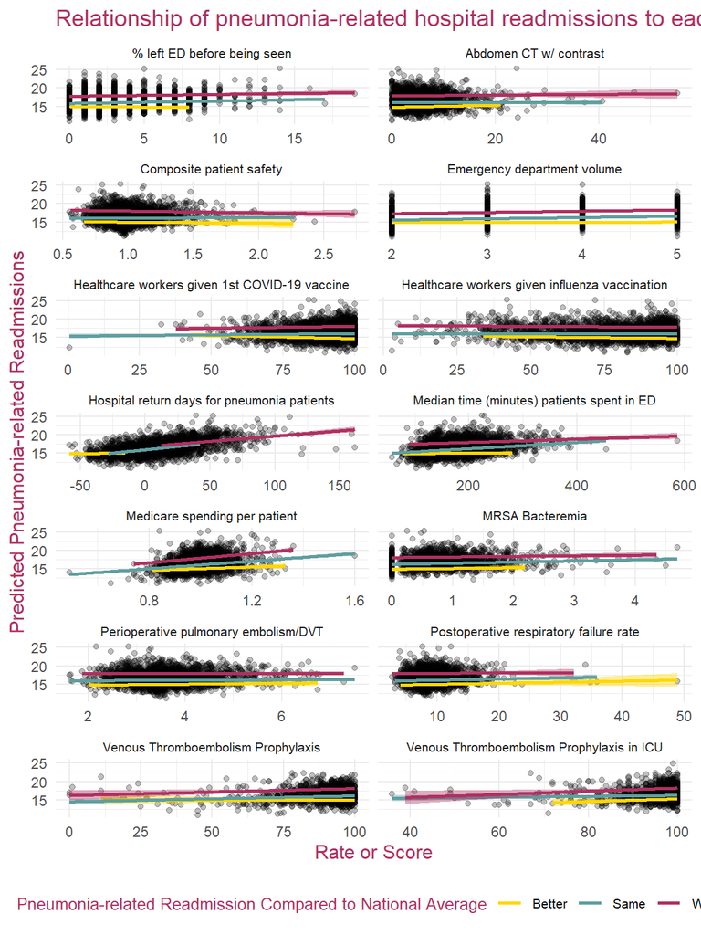

##### **Question 1**: [1 point]

Use the code above, or write your own *de novo*, to explore the relationships between the predicted pneumonia readmissions and the `HcahpsLinear...` variables.

```r
# #Malek
longDataScore2 <- pneumoniaAnalyzeDemo %>%
  rename(NatlComparisonHospitalDays = `ComparedToNational_Hospital return days for pneumonia patients`) %>%
  select(contains(c("NatlComparisonHospitalDays", "PredictedReadmissionRate", "HcahpsLinear"))) %>%
  pivot_longer(-c(1, 2, 12), names_to = "Variable2", values_to = "Value2") %>%
  drop_na() %>%
  mutate(Variable2 = gsub("Score_", "", Variable2)) %>%
  mutate(Variable2 = ifelse(Variable2 == "Average (median) time patients spent in the emergency department before leaving from the visit A lower number of minutes is better", "Median time (minutes) patients spent in ED",
                    ifelse(Variable2 == "CMS Medicare PSI 90: Patient safety and adverse events composite", "Composite patient safety",
                    ifelse(Variable2 == "Abdomen CT Use of Contrast Material", "Abdomen CT w/ contrast",
                    ifelse(Variable2 == "Perioperative pulmonary embolism or deep vein thrombosis rate", "Perioperative pulmonary embolism/DVT",
                    ifelse(Variable2 == "Percentage of healthcare personnel who completed COVID-19 primary vaccination series", "Healthcare workers given 1st COVID-19 vaccine",           ifelse(Variable2 == "Left before being seen", "% left ED before being seen",
                    ifelse(Variable2 == "Intensive Care Unit Venous Thromboembolism Prophylaxis", "Venous Thromboembolism Prophylaxis in ICU", Variable2))))))),
         NatlComparisonHospitalDays = ifelse(NatlComparisonHospitalDays == 1, "Better",
                                      ifelse(NatlComparisonHospitalDays == -1, "Worse",
                                      ifelse(NatlComparisonHospitalDays == 0, "Same", NatlComparisonHospitalDays))))
```

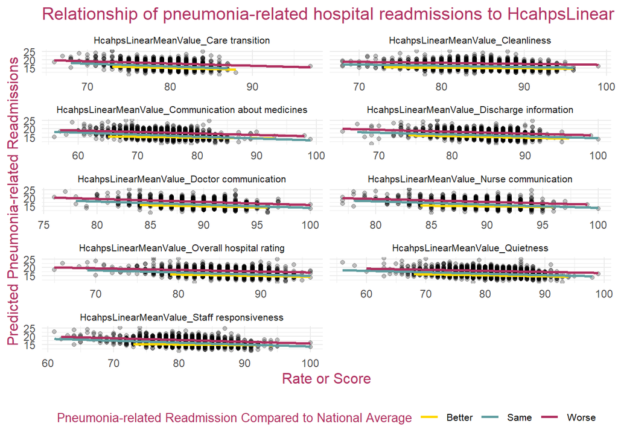

```r
longDataScore2 %>%
  ggplot(aes(y = PredictedReadmissionRate,
             x = Value2)) +
    geom_point(alpha = 0.25) +
    geom_smooth(aes(fill = as.factor(NatlComparisonHospitalDays),
                    color = as.factor(NatlComparisonHospitalDays)),
                method = "lm",
                se = TRUE,
                show.legend = TRUE) +
    labs(title = "Relationship of pneumonia-related hospital readmissions to HcahpsLinear variables",
         x = "Rate or Score",
         y = "Predicted Pneumonia-related Readmissions",
         color = "Pneumonia-related Readmission Compared to National Average") +
    scale_fill_manual(values = c("gold", "cadetblue", "maroon")) +
    scale_color_manual(values = c("gold", "cadetblue", "maroon"),
                       labels = c("Better", "Same", "Worse")) +
    guides(fill = "none", color = guide_legend(override.aes = list(fill = NA))) +
    theme_minimal() +
    theme(legend.position = "bottom",
          strip.text = element_text(size = 8),
          legend.text = element_text(size = 8),
          legend.title = element_text(size = 10),
          title = element_text(size = 12, color = "maroon")) +
    facet_wrap(~ Variable2,
               scales = "free_x",
               ncol = 2)
```

##### **Question 2**: [1 point]

What relationships do you find most compelling from your graphic and why? Also, name one outstanding question you have at this point, whether it is about the data, the data collection, or something more speculative.

> #Malek The relationship that stands out to me the most would be that of the hospital rating as well as the cleanliness. For both of these graphics we see similar shapes. One thing that I am curious of is if the cleanliness or rating actually could potentially play a role in the outcome of patients.

Although there is certainly more EDA we could do, we are going to wrap that up here for the sake of moving on - but, as always, I encourage you to think about or even explore what else you would like to know about your data that we did not do!

### 2.5 Final remarks on target selection.

I am sure you have noticed by know that, even though I made kind of a big deal about how well our crude measure seemed to reflect the number of hospital days, I ultimately seem to have chosen the `Predicted Readmission Rate`. In a full analysis, we might consider further exploring a best choice - or even circling back to our stakeholder and trying to refine our question - as we try to choose a target. The one thing that becomes clear, I hope, from these large, national studies is that using the **adjusted** values will generally always be a better choice than the crude, even if our crude measure captures something interesting about the data, as we did here. Our crude measure, `observed_readmission_rate` did the **best job** of recapitulating the `Number of Hospital Days`, but if that’s really our focus, wouldn’t it then be better to switch from a readmission rate to the number of hospital days?

But remember that what matters most is that we are **matching our question**.

#### Bias and Limitation

##### **Question 3**: [1 point]

All studies have bias (introduced or systemic error) and limitations (failure to fully explain something). We could go more deeply into these concepts, but for now I want you to take a stab and just brainstorming either ways we might have bias OR the limitations of using this target variable. You do not need to answer both, but you’re welcome to do so. You can read more about bias [here](https://www.ncbi.nlm.nih.gov/books/NBK574513/) or see some deeper explanations of limitations [here](https://www.aje.com/arc/how-to-write-limitations-of-the-study/). You do not need to write a lot; just 2-3 sentences. I am simply asking you to pause and reflect on our choices here before we proceed.

> #Malek One potential bias in using the Predicted Readmission Rate as our target variable is selection bias. The thing that is making me weary here is that the data is pretty reliant on historical data which may or may not be up to date. Thus, if one hospital has more data than another that is really covering all the bases then I believe this would definitely be shown in the outcomes.

# 3 Pre-processing and Feature Selection

The time has finally come to officially move **back** into pre-processing and feature selection so that we can finally build some models. I want you to take note of the order in which I’m doing things here; the flow can change from project to project, but generally it’s a good idea to get your dataset to a state of **manually curated features** before doing imputation and certainly before you’d make your train-test split. Another big thing to notice is that any scaling would be done **AFTER** a train-test split usually, with the exception of unusual situations like our gene expression analysis in Weeks 1 & 2.

## 3.1 Further feature selection and refinement.

### 3.1.1 Dropping the targets we aren’t planning to use. [Manual Method]

It’s time to say goodbye to the features we know would be far too redundant or non-informative given our target of `PredictedReadmissionRate`. We don’t need any of the `Sample_` columns, for example; these are merely sample sizes. Useful if we were doing standardization, but not necessary for us right now. We also are dropping the other possible target features that are too redundant with `PredictedReadmissionRate`.

```r
pneumoniaAnalyzeDemo <- pneumoniaAnalyzeDemo %>%
  select(-ExpectedReadmissionRate,
         -ExcessReadmissionRatio,
         -observed_readmission_rate,
         -contains(c("Sample_", "NumberOfPatients")),
         -NumberSurveysCompleted) %>%
  rename(`Median time (minutes) patients spent in ED` = `Score_Average (median) time patients spent in the emergency department before leaving from the visit A lower number of minutes is better`,
         `Composite patient safety` = `Score_CMS Medicare PSI 90: Patient safety and adverse events composite`,
         `ComparedToNational_Composite patient safety` = `ComparedToNational_CMS Medicare PSI 90: Patient safety and adverse events composite`,
         `Healthcare workers given 1st COVID-19 vaccine` = `Score_Percentage of healthcare personnel who completed COVID-19 primary vaccination series`)

## Clean up the column names quickly - remove "Score_", "HcahpsLinearMeanValue_", "_Payment"
colnames(pneumoniaAnalyzeDemo) <- gsub('Score_|HcahpsLinearMeanValue_|_Payment', '', colnames(pneumoniaAnalyzeDemo))
```

##### **Question 4**: [1 point]

Why do you think I choose to keep `Hospital return days for pneumonia patients` and `ComparedToNational_Hospital return days for pneumonia patients`? Do you agree with my choice? Why or why not? What analytic pitfalls are there to including them?

> #Malek I would say that I do agree with your choice… Probably always best to agree with you in these situations as there is likely a reason why you did what you did haha. Anyways, I like keeping both of them in there as it gives some kind of standard for us to use and compare with. As long as things aren.t becoming redundant, which I don’t believe they are in this case, then we should be in good shape.

### 3.1.2 Dropping any features with near-zero variance. [Automated Method]

Next, we are going to take advantage of the `nearZeroVar()` function that is part of the `caret` package. We will drop any of the columns with near-zero variance. This is a way of automating (and thus standardizing) the process for choosing to drop non-informative columns due to zero or nearly zero variance.

Table 3. Columns dropped due to near-zero variance.

| Variable |
| --- |
| PaymentCategory for pneumonia patients |
| ComparedToNational_Postoperative respiratory failure rate |
| ComparedToNational_Perioperative pulmonary embolism or deep vein thrombosis rate |

We can see that we lost three more features due to near-zero variance, bringing our total number of features down to 33. We’re getting closer to something manageable! You also may not have caught this yet, but I had moved `FacilityID` to our rownames – this just gets that out of the way too.

##### **Question 5**: [1 point]

If you are not familiar yet with the concept of **zero or near-zero variance**, do a little digging. Based on what you read, try to explain for your naive advocacy group stakeholders, why it’s important to remove the features with little variance.

> #Malek So, zero or near-zero variance deals with data that is pretty much exactly the same and thus the information is redundant and not useful. The problem arises when trying to build our models and all this data is doing is creating noise. Ultimately making our models less helpful. When these are removed the models are better able to focus on the important things.

##### **Question 6**: [1 point]

Why do I want to make sure unique identifiers, like `FacilityID`, are out of the dataframe for before I either run `nearZeroVar()` or proceeding with the rest of the analysis? What problems does keeping them in there create?

> #Malek Unique identifiers need to get removed because they can cause a disturbance in the models and understanding the data. These are not data points we are analyzing and are really just indicators of facilites in this case and thus there isn’t anything to analyze

## 3.2 Assess missingness & devise an imputation plan

We are going to deal with imputation in a rather quick and elegant way that requires minimal effort from us. Why? We aren’t focusing much on imputation this time, even though we *could* and our cursory treatment isn’t to suggest that it isn’t important! Instead, I want us to focus on the remainder of the analysis as we work through the data science analytical steps on the hospital readmissions data. Thus, I absolutely encourage you to look more deeply into imputation effects and options, but it’s beyond our scope during this project.

We are going to leverage the packages `mice` and `missForest` for assessing and dealing with missingness. I am sure you have already noticed how much of the dataset is missing. Ouch! Now, we do not want to impute anything with our target, `PredictedReadmissionRate`, so we will want to make sure to drop that before imputation. However, we can take a look at it with regard to the remainder of our variables to assess the extent of the missingness problem.

### Use the `md.pairs()` function from the `mice` package to assess the extent of missing values before imputing.

I am dropping `FacilityID` and `State` from the matrix, as they are not missing and can actually create errors. I am at this stage **keeping** `PredictedReadmissionRate` in the matrix so we can see with which other variables it has the higher correlations of missingness. Why? This will let us know where we are going to lose other information so we can make informed decisions about whether we want to keep those features going forward or not. What we’re looking for here is a pattern of missingness such that for each pair of columns $(Y_j, Y_k)$ the proportion of shared missingness.

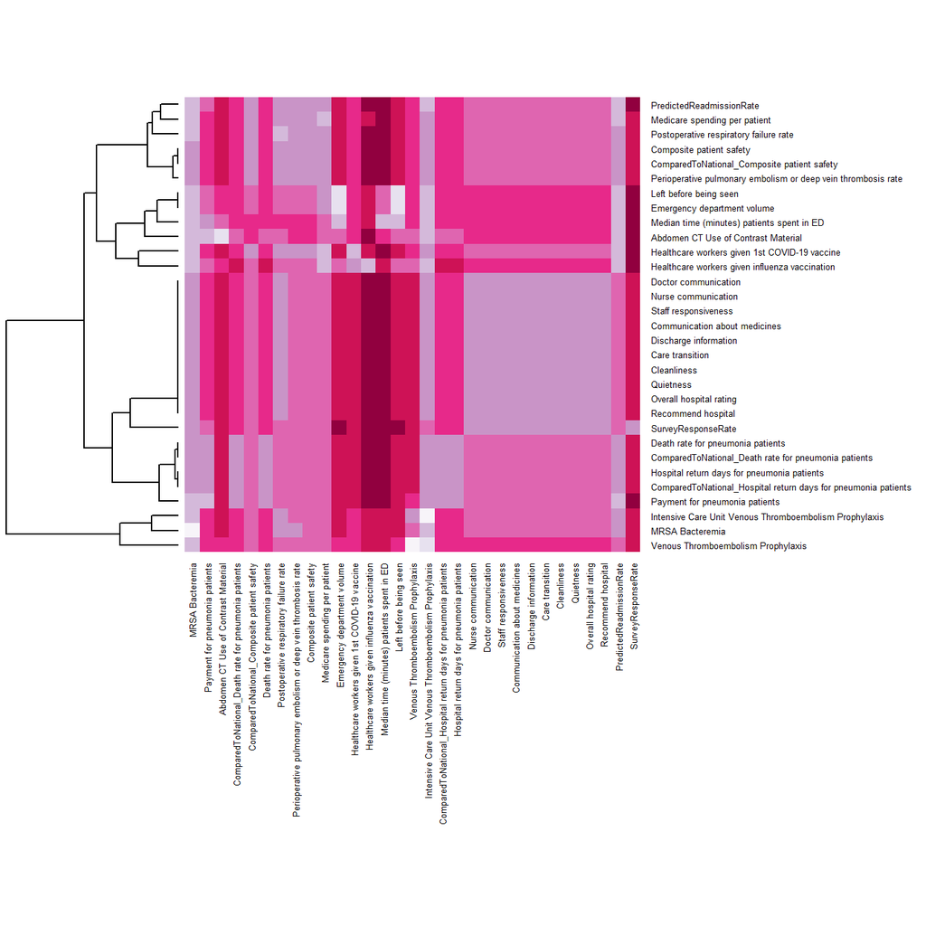

```r
# Drop ID and State and analyze the missingness in pairs using the mice package
p <- md.pairs(pneumoniaAnalyzeDemo[,-c(1:2)])
## Calculate pairwise pattern of missingness, where value is missing in both columns being compared.
df <- as.matrix(p$mr/(p$mr+p$mm))
```

Darker colors mean higher degrees of correlated missingness. So, for example, we see a pretty high rate of missingness in the percent of healthcare workers correlated with most other variables in the dataset.

##### **Question 7**: [1 point]

What columns seem to be most correlated in terms of missingness with our target, `PredictedReadmissionRate`? Does this give you any cause for concern?

> #Malek SurveyResponseRate, healthcare workers given influenza vaccination, and median time patients spent in ED are all variables that are highly correlated missingness to the target variable. I would say that I am not concerned as there are plenty of other variables for the models to build off of that aren’t at high levels of missingness.

### Drop the rows that are missing from the target variable.

We will not be able to use those rows at all moving forward, sadly. That is going to reduce our sample size pretty sizably, from $N = 4,816$ to only $N = 2,726$.

```
## [1] "Rows: 2726"  "Columns: 33"
```

At this stage, we are ready to **impute** - but before we do that, we actually **ALWAYS** want to do our data partitioning first! (Same is true for centering and scaling, which we will do after imputation).

## 3.3 Split into training & testing sets.

You may recall that I mentioned that the optimal ratio is has been argued to be $\sqrt{p} : 1$, where $p$ is the number of parameters (which may or may not equal your predictors depending on your planned analysis). Note that you do not have to split only a single time; you could make different splits for different analyses, if needed. However, we are going to use a single split here for convenience.

Now, wouldn’t it be nice to have a handy function that could calculate the optimal split ratio for us? So, let’s write one! This is something you can use with ANY analysis going forward!

##### **Question 8**: [2 points]

There are three parts to this question to get it to all come together correctly. **Practice reading R code** #Malek * Comment the function to explain what it does (I’ve defined the arguments for you) * Run the function (fill in the blank) * Fill in the missing piece in the partitioning chunk below

```r
#Malek

calcSplitRatio <- function(p = NA, df) {
  ## @p  = the number of parameters. by default, if none are provided, the number of columns (predictors) in the dataset are used
  ## @df = the dataframe that will be used for the analysis

  ##With no p, it is set to the number of columns in the dataframe - 1
  if(is.na(p)) {
    p <- ncol(df) -1   ##parameters is columns - 1
  }

  ##So now we are builiding the test set size and using that important formula of (1/sqrt(p))
  test_N <- (1/sqrt(p))*nrow(pneumoniaAnalyzeDemo)
  ##Determines the proportion of test set compared to the whole data frame
  test_prop <- round((1/sqrt(p))*nrow(pneumoniaAnalyzeDemo)/nrow(pneumoniaAnalyzeDemo), 2)
  ##Training proportion, whatever the test isn't
  train_prop <- 1-test_prop

  ##Prints best ratio
  print(paste0("The ideal split ratio is ", train_prop, " : ", test_prop, " training:testing"))

  ##Returns training proportion
  return(train_prop)
}

## Fill in the blanks to run:
train_prop <- calcSplitRatio(df = pneumoniaAnalyzeDemo)
```

```
## [1] "The ideal split ratio is 0.82 : 0.18 training:testing"
```

**Hint**: One important note here is that if the number of parameters are not provided (which is true for the starter code I gave you to run it - it does NOT pass any parameters to that argument!), then by default our function is designed to take the number of columns of the dataframe and subtract one for the target variable. Neat, huh?

```r
ind <- createDataPartition(pneumoniaAnalyzeDemo$PredictedReadmissionRate,                  ## Remember to put the target here!
                            p = train_prop,                                   ## Remember to use the object you just made from your function!
                            list = FALSE)

 train <- pneumoniaAnalyzeDemo[ind, ]
 test <- pneumoniaAnalyzeDemo[-c(ind), ]
```

```r
load(file = "pneumoniaTrain.Rdata")
load(file = "pneumoniaTest.Rdata")
```

## 3.4 Impute missing variables using `missForest`.

We are going to take advantage of the `missForest()` function from the `missForest` package. In a nutshell, what `missForest` does is it will fit either a regression- or classification-based random forest model and use the OOB results to predict and fill in NAs. The advantage is that this process is non-linear, done in just a few lines of code, and can handle mixed data-types (although you need to make sure that all your numerical types are of the same numerical type, and that all characters or factors are of the same type).

The way I have chosen to do this is to separate the data so that I can turn the encoded categories back into categories temporarily, then stitch them back together into a temporary dataframe so that I can run `missForest`. Notice that I temporarily drop the `State` and target features; this is to spare ourselves a little computational time. **Be patient**. As this is randomForest, it could take a minute or two to run.

Let’s look at a quick summary of the results.

Table 4. missForest OOB Error Rates for the imputed variables, training dataset

[output not shown]

##### **Question 9**: [1 point]

What does `MSE` and `PCF` indicate here? You may find looking at the `missForest` [Vignette](https://stat.ethz.ch/education/semesters/ss2012/ams/paper/missForest_1.2.pdf) helpful. How is the random forest that was performed here similar to what we performed on the gene expression data? How does this differ?

> #Malek This question was kind of confusing for me, but MSE I believe is the mean squared error. What is being measured in the mean squared error is the average of all the differences between the true and the estimated values. PCF, partial complete fraction looks at the proportion of correctly observed values. The thing that I want to point out here is that in gene expression the forests are applied based on gene expression patterns, but on the flip side missforest looks at missing values and builds forests from there I believe.

We are almost done. The last thing we need to do is extract the imputed values from `imputed_data$ximp`, and add the `State` and target variables back on. Then, we need to turn the factor features back into numbers for our next analyses.

**Notice** a bit of annoying trickery here. Because we had converted them to a factor type (as **required** by `missForest`), in order to back-convert them correctly to our original ordinal encoding, we had to first convert to character and then to numeric. So, our conversion went **factor** $\rightarrow$ **character** $\rightarrow$ **numeric** in order to get exactly what we wanted!

```r
imputedTrain <- imputedTrain$ximp %>%
  ## Put the original State and target variables back on
  mutate(State = train$State,
         PredictedReadmissionRate = train$PredictedReadmissionRate) %>%
  ## Convert the factors back to character type...
  mutate_at(c("Emergency department volume",
              "ComparedToNational_MRSA Bacteremia",
              "ComparedToNational_Composite patient safety",
              "ComparedToNational_Death rate for pneumonia patients",
              "ComparedToNational_Hospital return days for pneumonia patients"),
            as.character) %>%
  ## ... so we can then convert them back to numeric type.
  mutate_at(c("Emergency department volume",
              "ComparedToNational_MRSA Bacteremia",
              "ComparedToNational_Composite patient safety",
              "ComparedToNational_Death rate for pneumonia patients",
              "ComparedToNational_Hospital return days for pneumonia patients"),
            as.numeric)

## Save data files so they can be loaded for future use
# save(imputedTrain, file = "imputedTrain.Rdata")
```

##### **Question 10**: [1 point]

Now repeat the imputation steps for the `test` dataset, storing it into `imputedTest`.

```r
## Ryan C

# Remove encoded categorical variables for imputation, plus the target and state (which have no missing)
data_sans_encoded_test <- test %>%
  select(-PredictedReadmissionRate,
         -State,
         -`Emergency department volume`,
         -contains("ComparedToNational"))

data_cat_test <- test %>%
  select(`Emergency department volume`,
         contains("ComparedToNational")) %>%
  mutate_all(as.factor)

# Stitch them back together:
temp_test <- cbind(data_sans_encoded_test, data_cat_test)

# Impute missing values using missForest for the test dataset
imputedTest <- missForest(temp_test,
                          variablewise = TRUE,
                          verbose = FALSE)
## Malek
# Convert factors back to numeric type in the imputedTest dataset
imputedTest <- imputedTest$ximp %>%
  ## Put the original State and target variables back on
  mutate(State = test$State,
         PredictedReadmissionRate = test$PredictedReadmissionRate) %>%
  ## Convert the factors back to character type...
  mutate_at(c("Emergency department volume",
              "ComparedToNational_MRSA Bacteremia",
              "ComparedToNational_Composite patient safety",
              "ComparedToNational_Death rate for pneumonia patients",
              "ComparedToNational_Hospital return days for pneumonia patients"),
            as.character) %>%
  ## ... so we can then convert them back to numeric type.
  mutate_at(c("Emergency department volume",
              "ComparedToNational_MRSA Bacteremia",
              "ComparedToNational_Composite patient safety",
              "ComparedToNational_Death rate for pneumonia patients",
              "ComparedToNational_Hospital return days for pneumonia patients"),
            as.numeric)

## Save data files so they can be loaded for future use
# save(imputedTest, file = "imputedTest.Rdata")
```

##### **Question 11**: [1 point]

Quickly explore how well the imputation did by choosing at least one numeric variable and one of the categorical variables. Did the distributions or frequencies change drastically?

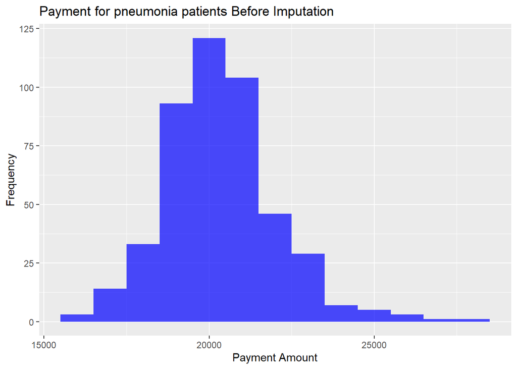

```r
# Plot distribution before imputation (using imputed test data as a proxy)
ggplot(imputedTest, aes(x = `Payment for pneumonia patients`)) +
  geom_histogram(binwidth = 1000, fill = "blue", alpha = 0.7) +
  ggtitle("Payment for pneumonia patients Before Imputation") +
  xlab("Payment Amount") +
  ylab("Frequency")
```

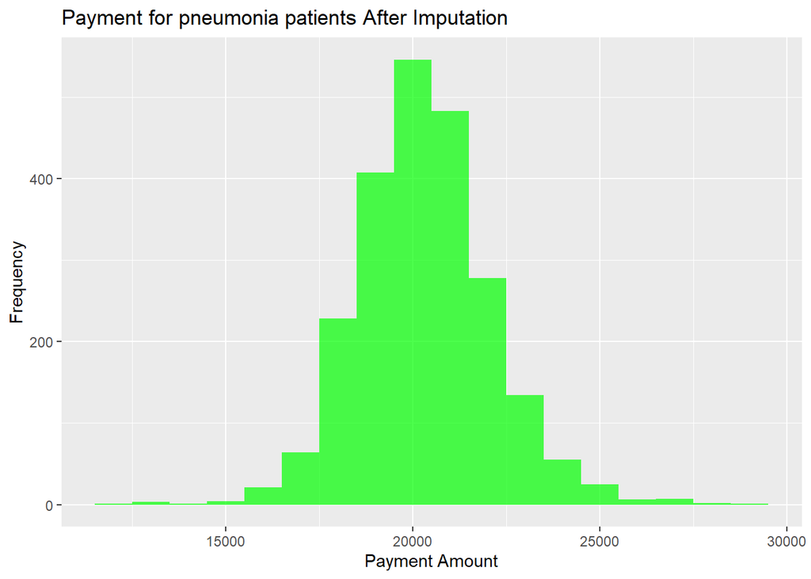

```r
# Plot distribution after imputation (using imputed train data)
ggplot(imputedTrain, aes(x = `Payment for pneumonia patients`)) +
  geom_histogram(binwidth = 1000, fill = "green", alpha = 0.7) +
  ggtitle("Payment for pneumonia patients After Imputation") +
  xlab("Payment Amount") +
  ylab("Frequency")
```

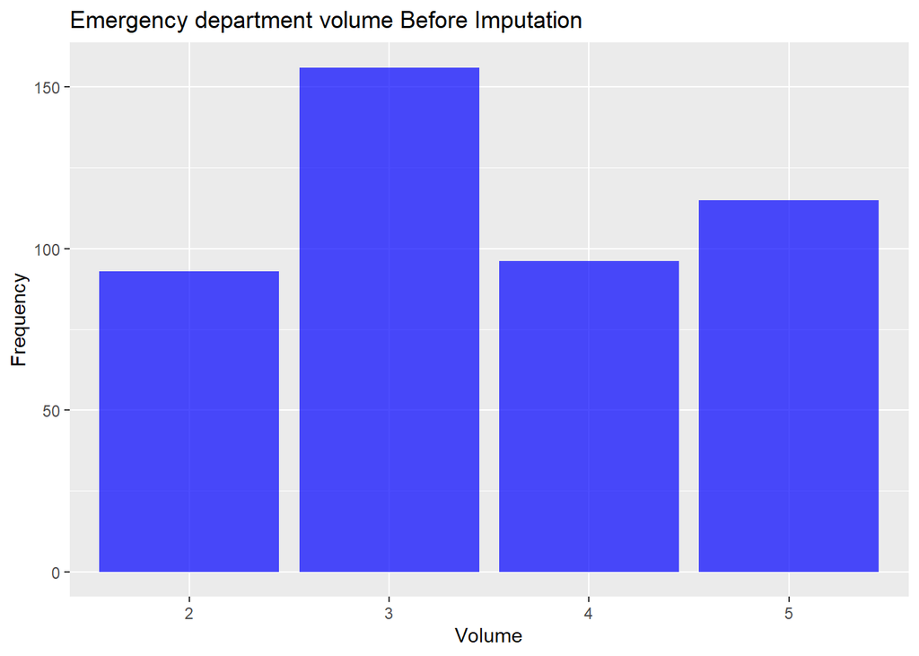

```r
# Categorical variable: Emergency department volume
# Plot frequencies before imputation (using imputed test data as a proxy)
ggplot(imputedTest, aes(x = factor(`Emergency department volume`))) +
  geom_bar(fill = "blue", alpha = 0.7) +
  ggtitle("Emergency department volume Before Imputation") +
  xlab("Volume") +
  ylab("Frequency")
```

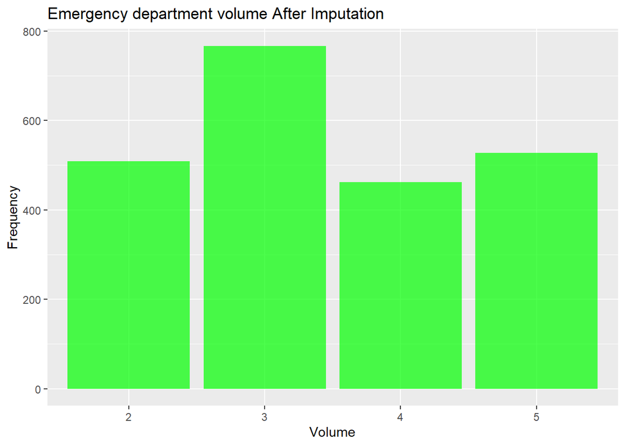

```r
# Plot frequencies after imputation (using imputed train data)
ggplot(imputedTrain, aes(x = factor(`Emergency department volume`))) +
  geom_bar(fill = "green", alpha = 0.7) +
  ggtitle("Emergency department volume After Imputation") +
  xlab("Volume") +
  ylab("Frequency")
```

> Your answer here.It looks like it did not change.

# Struggling? Here’s my solution:

```r
# source(file = "answer_question11.R", echo = TRUE)
```

## 3.5 Transformation & Scaling

Ultimately, we know we will need to scale & center our data, as that is required for the analyses I have set out in our Analysis Plan. But before we get into that, it would be nice to know what **realm of analyses** in which we fall and, more importantly, do we need to consider *transformation* of our target in addition to the scaling & centering we plan to do on the entire dataset.

**In other words: is our target variable approximately normally distributed?**

[figure not shown]

##### **Question 12**: [1 point]

Why is a histogram, or even a Q-Q plot, an insufficient way to assess whether a distribution is approximately normal?

> Your answer here.hile histograms and Q-Q plots are useful tools for visualizing data distributions and checking for normality, they have limitations that make them insufficient on their own to conclusively determine whether a distribution is approximately normal.

##### **Question 13**: [1 point]

Apply a Shapiro-Wilk test for normality using the `shapiro.test()` function. What does it indicate about your distribution? (**Note**: Shapiro tests are only reliable for $N < 5000$, but it is fine to perform here.)

```r
shapiro_test_result <- shapiro.test(imputedTrain$PredictedReadmissionRate)

# Print the test result
print(shapiro_test_result)
```

```
##
##  Shapiro-Wilk normality test
##
## data:  imputedTrain$PredictedReadmissionRate
## W = 0.98758, p-value = 0.0000000000003941
```

> Your answer here.The p-value is much smaller than the common alpha level of 0.05, which means we reject the null hypothesis. The null hypothesis of the Shapiro-Wilk test is that the data is normally distributed. Since we reject the null hypothesis, we conclude that the PredictedReadmissionRate does not follow a normal distribution.

### 3.5.1 Box-Cox Transformation

Recall from our brief discussion in lecture that the Box-Cox transformation involves the parameter $\lambda$, which when applied to $y$ yields the transformation.

There are multiple ways to apply the Box-Cox transform in R, but we are going to take advantage of the one in `caret` to make our lives easier, `BoxCoxTrans()`.

```r
bc_data <- BoxCoxTrans(imputedTrain$PredictedReadmissionRate)
bc_data
```

```
## Box-Cox Transformation
##
## 2266 data points used to estimate Lambda
##
## Input data summary:
##    Min. 1st Qu.  Median    Mean 3rd Qu.    Max.
##   10.90   15.14   16.27   16.46   17.62   25.19
##
## Largest/Smallest: 2.31
## Sample Skewness: 0.473
##
## Estimated Lambda: -0.3
```

Now apply the Box-Cox transformation:

```r
imputedTrain$bc_PredictedReadmissionRate <- predict(bc_data, imputedTrain$PredictedReadmissionRate)
```

[figure not shown]

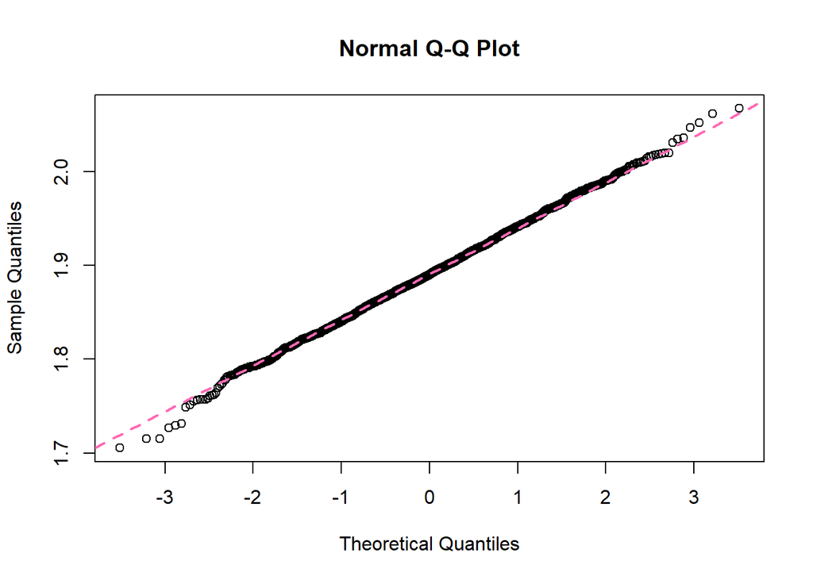

Can you tell what it did to the distribution? **Look closely**, if not. It’s subtle but discernible.It looks like a normal QQ plot for the normilised quantile residuals, In other words distribution looks normalized